# Gapminder

## “Como a expectativa de vida (**lifeExp**) muda com o tempo (**year**) em cada país (**country**)?”

```
Classes ‘tbl_df’, ‘tbl’ and 'data.frame':   1704 obs. of  6 variables:
 $ country  : Factor w/ 142 levels "Afghanistan",..: 1 1 1 1 1 1 1 1 1 1 ...
 $ continent: Factor w/ 5 levels "Africa","Americas",..: 3 3 3 3 3 3 3 3 3 3 ...
 $ year     : int  1952 1957 1962 1967 1972 1977 1982 1987 1992 1997 ...
 $ lifeExp  : num  28.8 30.3 32 34 36.1 ...
 $ pop      : int  8425333 9240934 10267083 11537966 13079460 14880372 12881816 13867957 16317921 22227415 ...
 $ gdpPercap: num  779 821 853 836 740 ...
```

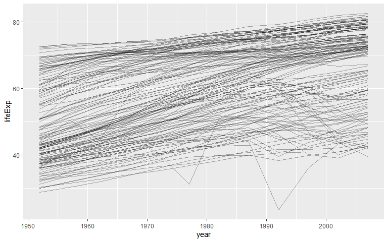

Olhando o gráfico podemos dizer que no geral a expectativa de vida tem um crescimento forte, com algumas excessões, como podemos tratar estas tendências e olhar as características mais sutis. Vamos desembaraçar esse fatores ajustando um modelo com uma tendência linear. O modelo captura o crescimento constante ao longo do tempo, e os resíduos mostrarão o que restou.

Fazendo primeiramente para um único país:

- Nova Zelândia:

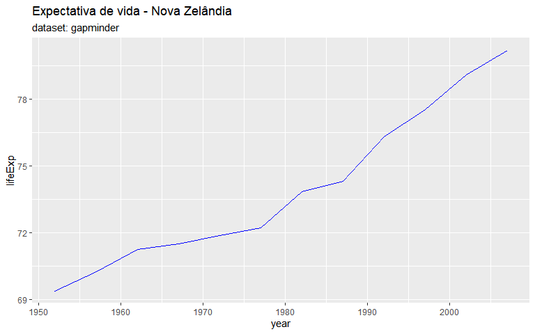

### Broom:

Broom define metódos tydy para extrair 3 tipos de estatísticas de um objeto.

1. **tidy()** : informações sobre as estimativas feitas pelo modelo e informações estatísticas relacionadas em um formato de data frame. - (Component level : *coeficientes, p-values*)
2. **augment()** : observações estatísticas - (Observation level: *fitted values, residuals*)
3. **glance()** : estatísticas do modelo - (Model Level: **)

```
[1] "tbl_df"     "tbl"        "data.frame"
```

| term | estimate | std.error | statistic | p.value |
| --- | --- | --- | --- | --- |
| (Intercept) | -307.6996 | 26.63039 | -11.55 | 4.166e-07 |
| year | 0.1928 | 0.01345 | 14.33 | 5.407e-08 |

| lifeExp | year | .fitted | .se.fit | .resid | .hat | .sigma | .cooksd | .std.resid |
| --- | --- | --- | --- | --- | --- | --- | --- | --- |
| 69.39 | 1952 | 68.69 | 0.4368 | 0.70308 | 0.29487 | 0.8006 | 0.2265613 | 1.04094 |
| 70.26 | 1957 | 69.65 | 0.3815 | 0.60897 | 0.22494 | 0.8159 | 0.1073196 | 0.85998 |
| 71.24 | 1962 | 70.62 | 0.3307 | 0.62487 | 0.16900 | 0.8165 | 0.0738473 | 0.85220 |
| 71.52 | 1967 | 71.58 | 0.2867 | -0.05924 | 0.12704 | 0.8476 | 0.0004521 | -0.07882 |
| 71.89 | 1972 | 72.54 | 0.2532 | -0.65334 | 0.09907 | 0.8162 | 0.0402636 | -0.85576 |
| 72.22 | 1977 | 73.51 | 0.2346 | -1.28745 | 0.08508 | 0.7194 | 0.1302006 | -1.67338 |
| 73.84 | 1982 | 74.47 | 0.2346 | -0.63155 | 0.08508 | 0.8188 | 0.0313309 | -0.82087 |
| 74.32 | 1987 | 75.44 | 0.2532 | -1.11566 | 0.09907 | 0.7519 | 0.1174064 | -1.46131 |
| 76.33 | 1992 | 76.40 | 0.2867 | -0.06976 | 0.12704 | 0.8475 | 0.0006270 | -0.09283 |
| 77.55 | 1997 | 77.36 | 0.3307 | 0.18613 | 0.16900 | 0.8451 | 0.0065525 | 0.25385 |

[output cut: 2 more lines]

| r.squared | adj.r.squared | sigma | statistic | p.value | df | logLik | AIC | BIC | deviance | df.residual |
| --- | --- | --- | --- | --- | --- | --- | --- | --- | --- | --- |
| 0.9536 | 0.9489 | 0.8043 | 205.4 | 5.407e-08 | 2 | -13.32 | 32.64 | 34.1 | 6.47 | 10 |

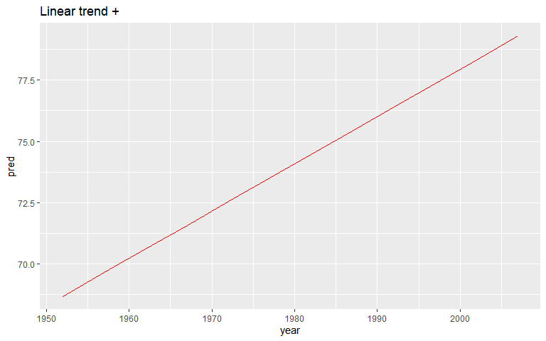

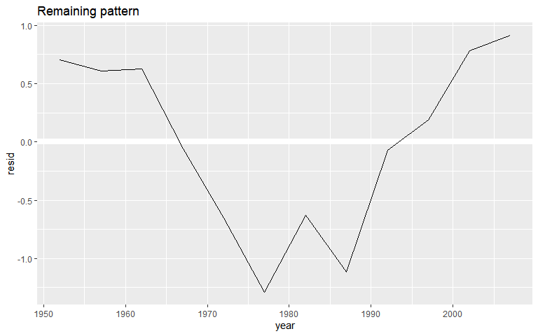

| year | lifeExp | pop | gdpPercap |
| --- | --- | --- | --- |
| 1952 | 28.80 | 8425333 | 779.4 |
| 1957 | 30.33 | 9240934 | 820.9 |
| 1962 | 32.00 | 10267083 | 853.1 |
| 1967 | 34.02 | 11537966 | 836.2 |
| 1972 | 36.09 | 13079460 | 740.0 |
| 1977 | 38.44 | 14880372 | 786.1 |
| 1982 | 39.85 | 12881816 | 978.0 |
| 1987 | 40.82 | 13867957 | 852.4 |
| 1992 | 41.67 | 16317921 | 649.3 |
| 1997 | 41.76 | 22227415 | 635.3 |

[output cut: 2 more lines]

| country | continent | data | model |
| --- | --- | --- | --- |
| Afghanistan | Asia |  |  |
| Albania | Europe |  |  |
| Algeria | Africa |  |  |
| Angola | Africa |  |  |
| Argentina | Americas |  |  |
| Australia | Oceania |  |  |
| Austria | Europe |  |  |
| Bahrain | Asia |  |  |
| Bangladesh | Asia |  |  |
| Belgium | Europe |  |  |

[output cut: 132 more lines]

| country | continent | data | model |
| --- | --- | --- | --- |
| Albania | Europe |  |  |
| Austria | Europe |  |  |
| Belgium | Europe |  |  |
| Bosnia and Herzegovina | Europe |  |  |
| Bulgaria | Europe |  |  |
| Croatia | Europe |  |  |
| Czech Republic | Europe |  |  |
| Denmark | Europe |  |  |
| Finland | Europe |  |  |
| France | Europe |  |  |

[output cut: 20 more lines]

| country | continent | data | model |
| --- | --- | --- | --- |
| Algeria | Africa |  |  |
| Angola | Africa |  |  |
| Benin | Africa |  |  |
| Botswana | Africa |  |  |
| Burkina Faso | Africa |  |  |
| Burundi | Africa |  |  |
| Cameroon | Africa |  |  |
| Central African Republic | Africa |  |  |
| Chad | Africa |  |  |
| Comoros | Africa |  |  |

[output cut: 132 more lines]

| country | continent | data | model | resids |
| --- | --- | --- | --- | --- |
| Afghanistan | Asia |  |  |  |
| Albania | Europe |  |  |  |
| Algeria | Africa |  |  |  |
| Angola | Africa |  |  |  |
| Argentina | Americas |  |  |  |
| Australia | Oceania |  |  |  |
| Austria | Europe |  |  |  |
| Bahrain | Asia |  |  |  |
| Bangladesh | Asia |  |  |  |
| Belgium | Europe |  |  |  |

[output cut: 132 more lines]

| country | continent | data | model | year | lifeExp | pop | gdpPercap | resid |
| --- | --- | --- | --- | --- | --- | --- | --- | --- |
| Afghanistan | Asia |  |  | 1952 | 28.80 | 8425333 | 779.4 | -1.106e+00 |
| Afghanistan | Asia |  |  | 1957 | 30.33 | 9240934 | 820.9 | -9.519e-01 |
| Afghanistan | Asia |  |  | 1962 | 32.00 | 10267083 | 853.1 | -6.636e-01 |
| Afghanistan | Asia |  |  | 1967 | 34.02 | 11537966 | 836.2 | -1.722e-02 |
| Afghanistan | Asia |  |  | 1972 | 36.09 | 13079460 | 740.0 | 6.741e-01 |
| Afghanistan | Asia |  |  | 1977 | 38.44 | 14880372 | 786.1 | 1.647e+00 |
| Afghanistan | Asia |  |  | 1982 | 39.85 | 12881816 | 978.0 | 1.687e+00 |
| Afghanistan | Asia |  |  | 1987 | 40.82 | 13867957 | 852.4 | 1.278e+00 |
| Afghanistan | Asia |  |  | 1992 | 41.67 | 16317921 | 649.3 | 7.536e-01 |
| Afghanistan | Asia |  |  | 1997 | 41.76 | 22227415 | 635.3 | -5.341e-01 |

[output cut: 990 more lines]

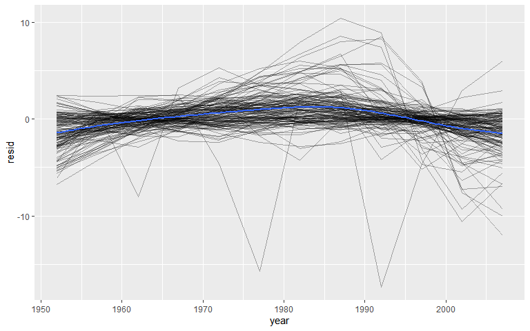

Fazer facetas por continente é particularmente revelador:

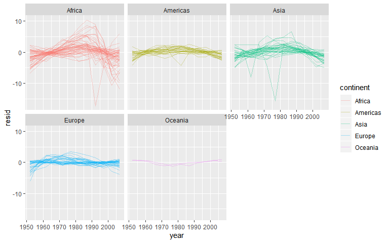

O pacote broom fornece um conjunto de funções gerais transformar modelos em dados **tidy**. O pacote bromm tem 3 principais funções, que são extrair informações do objeto que a função **lm** retorna e transforma-las numa versão amiga do **tidyverse**, data frame.

| country | continent | data | model | resids | r.squared | adj.r.squared | sigma | statistic | p.value | df | logLik | AIC | BIC | deviance | df.residual |
| --- | --- | --- | --- | --- | --- | --- | --- | --- | --- | --- | --- | --- | --- | --- | --- |
| Afghanistan | Asia |  |  |  | 0.94771 | 0.942483 | 1.2228 | 181.2494 | 9.835e-08 | 2 | -18.3469 | 42.6939 | 44.149 | 14.9521 | 10 |
| Albania | Europe |  |  |  | 0.91058 | 0.901636 | 1.9831 | 101.8290 | 1.463e-06 | 2 | -24.1490 | 54.2981 | 55.753 | 39.3253 | 10 |
| Algeria | Africa |  |  |  | 0.98512 | 0.983629 | 1.3230 | 661.9171 | 1.808e-10 | 2 | -19.2922 | 44.5844 | 46.039 | 17.5035 | 10 |
| Angola | Africa |  |  |  | 0.88781 | 0.876596 | 1.4070 | 79.1382 | 4.593e-06 | 2 | -20.0309 | 46.0619 | 47.517 | 19.7967 | 10 |
| Argentina | Americas |  |  |  | 0.99557 | 0.995125 | 0.2923 | 2246.3663 | 4.216e-13 | 2 | -1.1739 | 8.3479 | 9.803 | 0.8544 | 10 |
| Australia | Oceania |  |  |  | 0.97965 | 0.977613 | 0.6206 | 481.3459 | 8.667e-10 | 2 | -10.2087 | 26.4174 | 27.872 | 3.8516 | 10 |
| Austria | Europe |  |  |  | 0.99213 | 0.991347 | 0.4074 | 1261.2963 | 7.435e-12 | 2 | -5.1581 | 16.3162 | 17.771 | 1.6598 | 10 |
| Bahrain | Asia |  |  |  | 0.96674 | 0.963414 | 1.6396 | 290.6597 | 1.016e-08 | 2 | -21.8667 | 49.7333 | 51.188 | 26.8824 | 10 |
| Bangladesh | Asia |  |  |  | 0.98936 | 0.988297 | 0.9767 | 929.9264 | 3.370e-11 | 2 | -15.6503 | 37.3006 | 38.755 | 9.5392 | 10 |
| Belgium | Europe |  |  |  | 0.99454 | 0.993995 | 0.2929 | 1821.6884 | 1.196e-12 | 2 | -1.1983 | 8.3967 | 9.851 | 0.8579 | 10 |

[output cut: 132 more lines]